# Sequential trials

2022-08-17

VE from Novavax. This function takes the mean and 95% CI of vaccine effectiveness, converts to a log(RR), and estimates the precision fro the CIs, assuming it is symmetric around the mean (on scale of log(RR))

Set parameters for new trial population

## Scenario 1: Same VE as original trial

Novavax had 3045 vaccinees and 1581 controls; 2.4% in placebo group had primary endpoint in 90 days

## Scenario 2: no actual effect

## Scenario 3: discrepant actual effect

## At which points do we want to evaluate VE?

How many vaccinees are enrolled?

generate combined dataset for modeling–need to fill 0s if stratum not represented

```
##    user  system elapsed
##    0.21    0.03    0.23
```

Call all models for both simulated datasets. Use parallel processing

## Bayesian estimates of performance

### Trajectories for 500 trials

This shows how the probabilities evolve as more data accrue. This shows probability of any benefit: P(VE>0|data)

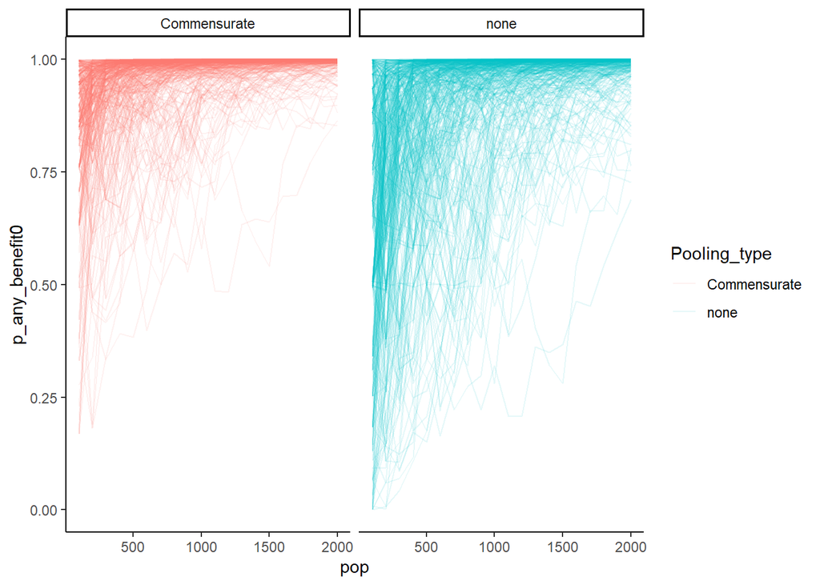

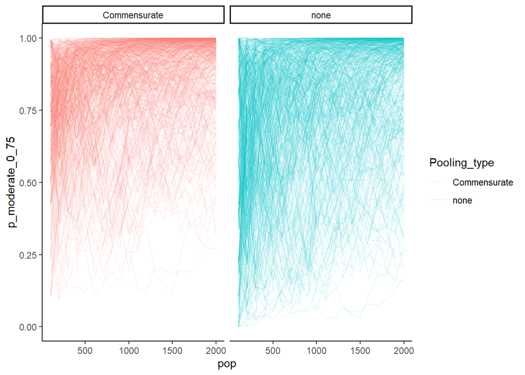

### Summaries of the trajectories

What is the probability of detecting any effect if there is (A) No effect (B) a moderate effect in line with the original trial or (C) A large effect, bigger than original trial? The shaded region shows where 90% of the estimates lie

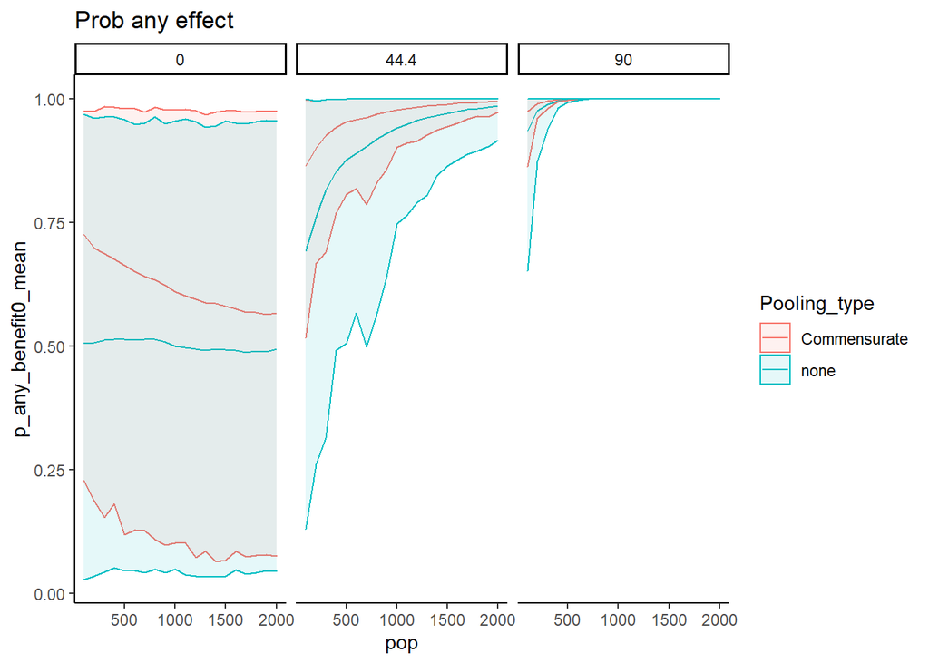

What is the probability of detecting NO effect (or effect between 20% decline or 25% increase) when the data truly have: (A) No effect (B) a moderate effect in line with the original trial or (C) A large effect, bigger than original trial? the shaded region shows where 90% of the estimates lie

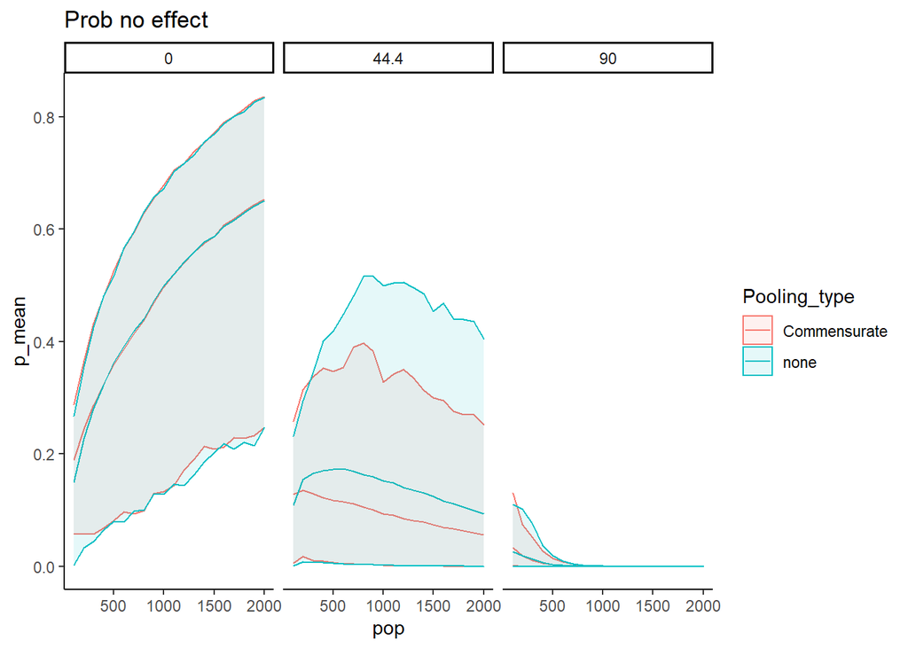

What is the probability of detecting a moderate effect or greater (at least 25% decline) effect when the data truly have: (A) No effect (B) a moderate effect in line with the original trial or (C) A large effect, bigger than original trial? the shaded region shows where 90% of the estimates lie

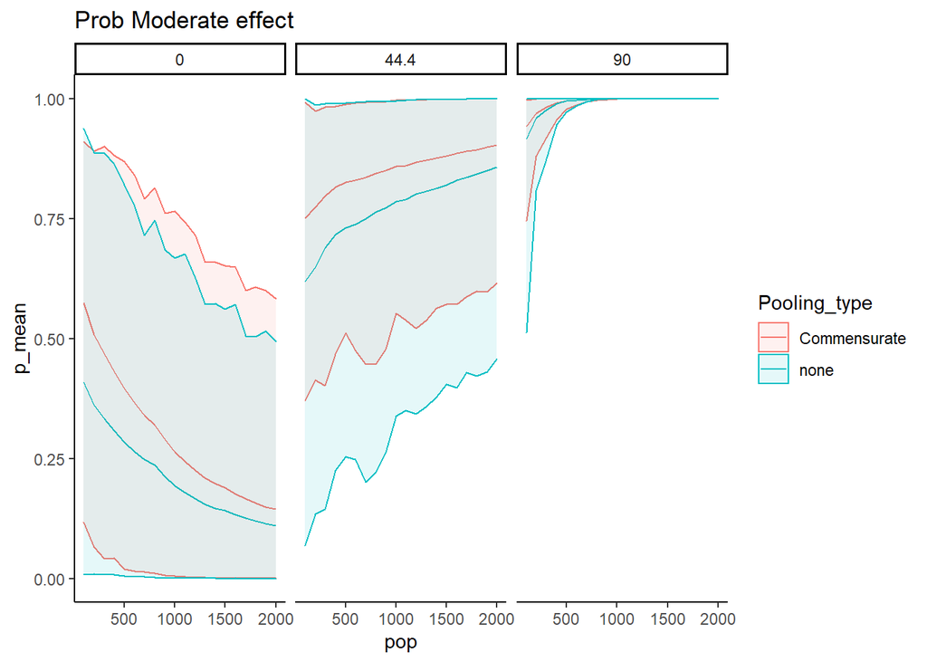

What is the probability of detecting a harmful effect or greater (an increase in disease rates) when the data truly have: (A) No effect (B) a moderate effect in line with the original trial or (C) A large effect, bigger than original trial? the shaded region shows where 90% of the estimates lie

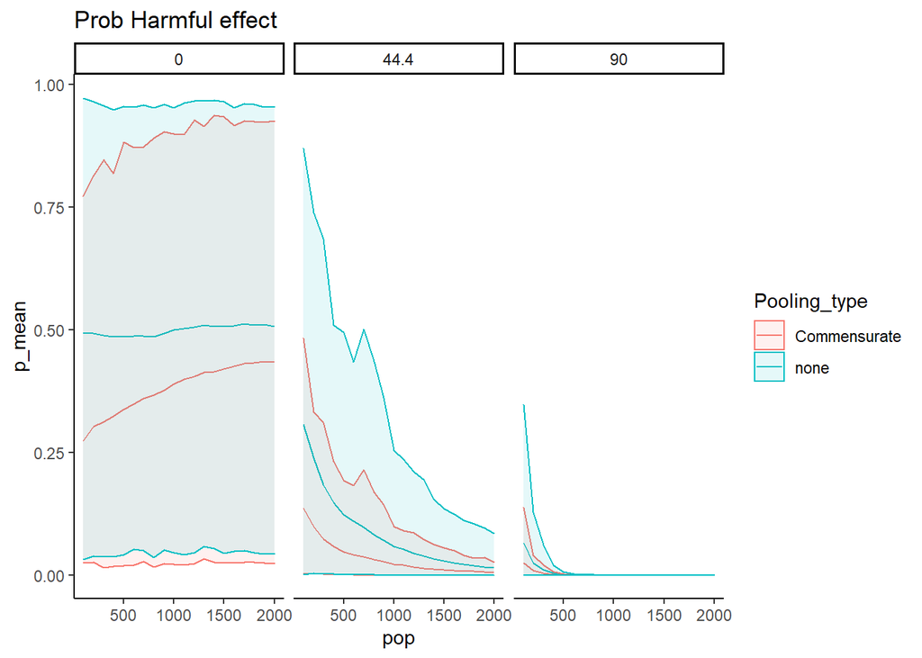

## Traditional frequentist measures of power, type 1 error

How do the three models perform when there is NO real effect?

1: no pooling 2: highly informative prior (full use) 3:Gamma, (4:Half-Cauchy 5: mixture model)

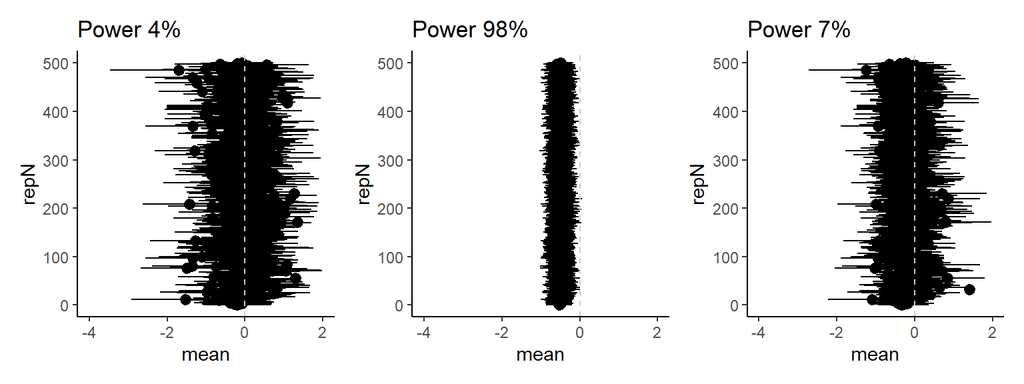

[figure not shown]

For a larger dataset

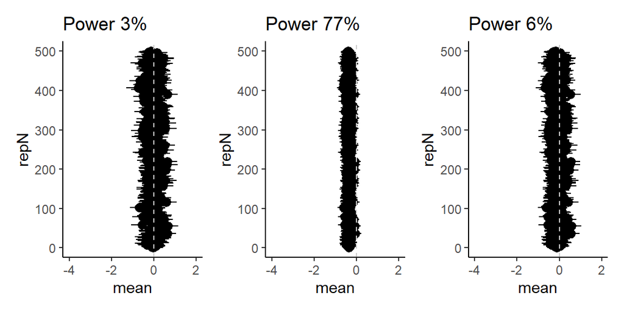

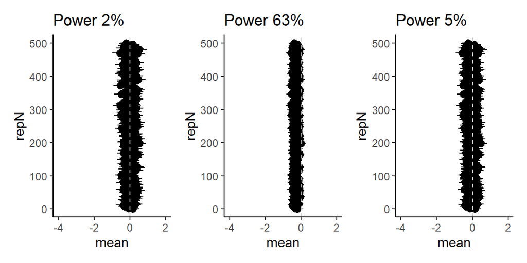

How do the three models perform when there is a real effect, consistent with the original?

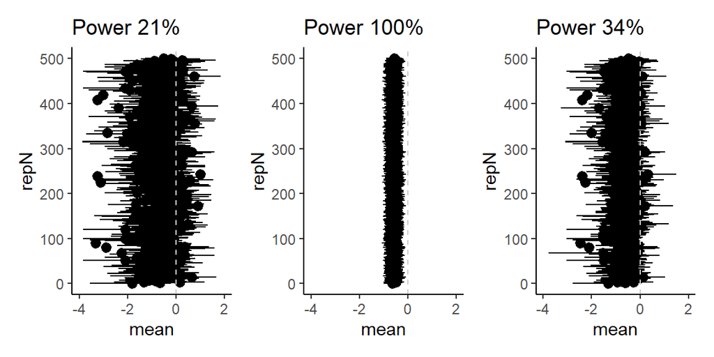

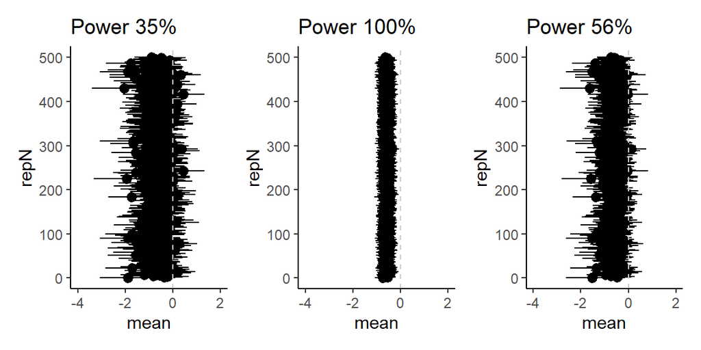

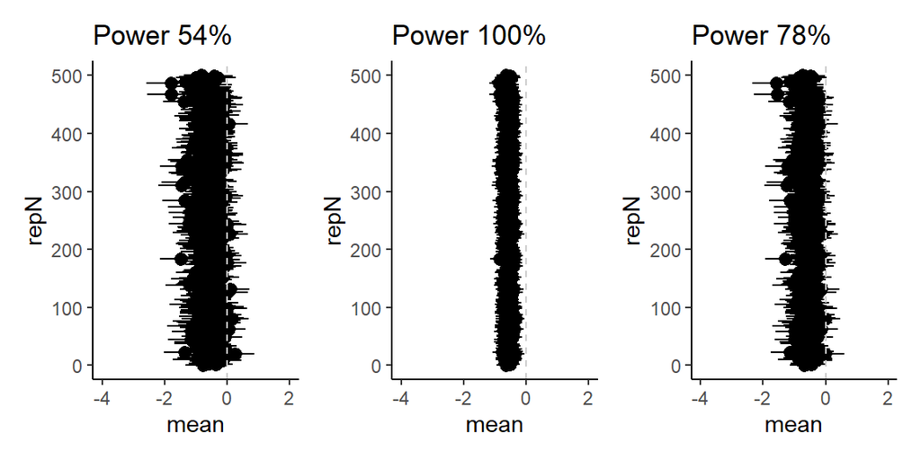

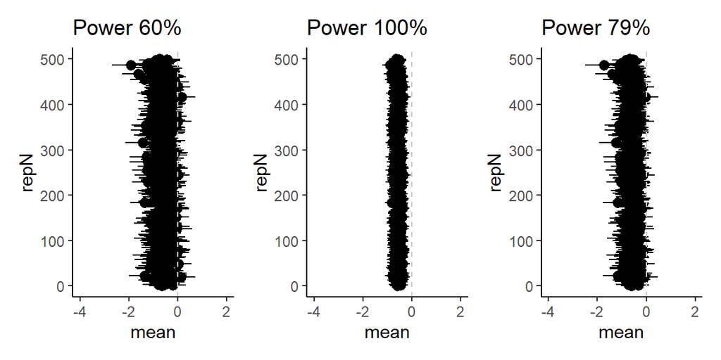

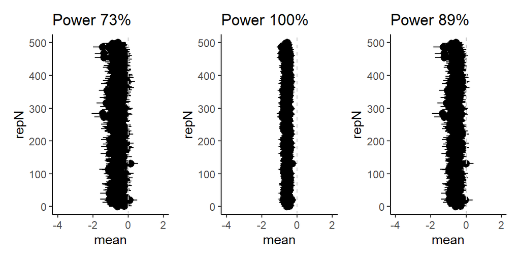

## What if there is a discrepant effect between prior and new trial

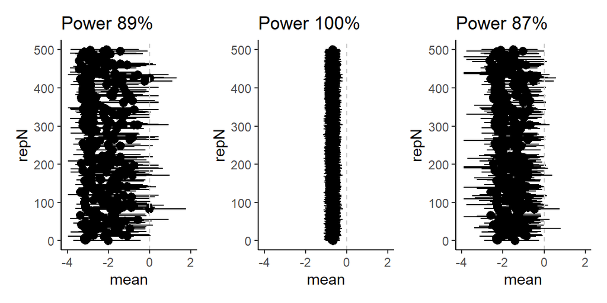

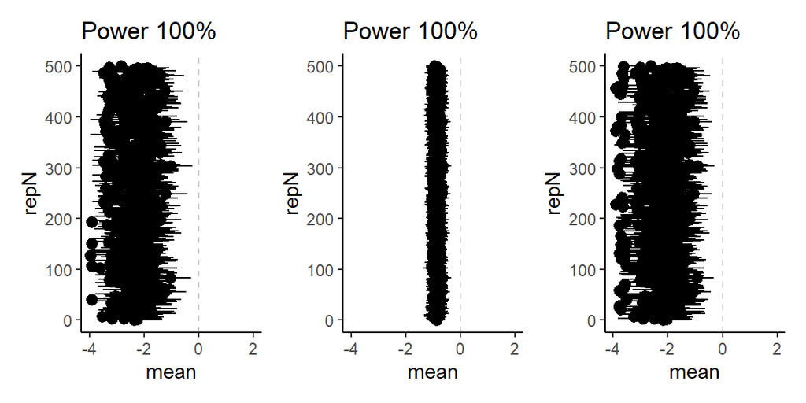

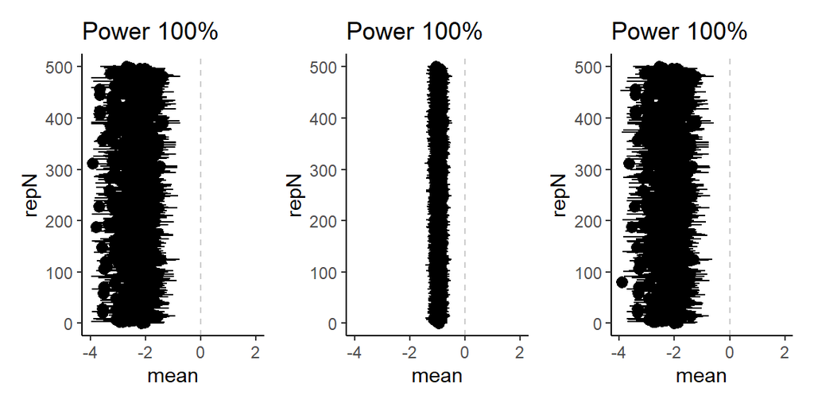